# Seinna R-verkefni

# Hluti 1

```r
as <- read.table("https://notendur.hi.is/~ahj/husnaedisverd_2017_21.csv", sep = ";", header = T, encoding = "UTF-8", stringsAsFactors = T )
```

2. Veljum þrjú hverfi til að skoða.

```r
hverfi <- c(200, 220, 270)
as <- filter(as, matssvaedi%in%hverfi)
```

```r
glimpse(as)
```

```
## Rows: 1,148
## Columns: 5
## $ kaupverd   <int> 18700, 15200, 17150, 19692, 21500, 22000, 18000, 14500, 249~
## $ teg_eign   <fct> Íbúðareign, Íbúðareign, Íbúðareign, Íbúðareign, Íbúðareign,~
## $ byggar     <int> 1970, 1967, 1983, 1967, 1967, 1986, 1967, 1967, 1967, 1985,~
## $ birtm2     <dbl> 123.7, 83.2, 76.1, 101.9, 120.4, 87.6, 110.0, 72.0, 125.7, ~
## $ matssvaedi <int> 200, 200, 220, 200, 200, 220, 200, 200, 200, 220, 200, 200,~
```

Allt í lagi með gerðir breyta.

```r
as <- mutate(as, fermetraverd = kaupverd/birtm2)
as <- mutate(as, fermetraverd = as.integer(fermetraverd))
glimpse(as)
```

```
## Rows: 1,148
## Columns: 6
## $ kaupverd     <int> 18700, 15200, 17150, 19692, 21500, 22000, 18000, 14500, 2~
## $ teg_eign     <fct> Íbúðareign, Íbúðareign, Íbúðareign, Íbúðareign, Íbúðareig~
## $ byggar       <int> 1970, 1967, 1983, 1967, 1967, 1986, 1967, 1967, 1967, 198~
## $ birtm2       <dbl> 123.7, 83.2, 76.1, 101.9, 120.4, 87.6, 110.0, 72.0, 125.7~
## $ matssvaedi   <int> 200, 200, 220, 200, 200, 220, 200, 200, 200, 220, 200, 20~
## $ fermetraverd <int> 151, 182, 225, 193, 178, 251, 163, 201, 198, 190, 175, 22~
```

```r
as <- mutate(as, if_else(teg_eign == "Íbúðareign", teg_eign_ser_ib <- "Íbúð", teg_eign_ser_ib <- "Sérbýli"))
glimpse(as)
```

```
## Rows: 1,148
## Columns: 7
## $ kaupverd       <int> 18700, 15200, 17150, 19692, 21500, 22000, 18000, 14500,~
## $ teg_eign       <fct> Íbúðareign, Íbúðareign, Íbúðareign, Íbúðareign, Íbúðare~
## $ byggar         <int> 1970, 1967, 1983, 1967, 1967, 1986, 1967, 1967, 1967, 1~
## $ birtm2         <dbl> 123.7, 83.2, 76.1, 101.9, 120.4, 87.6, 110.0, 72.0, 125~
## $ matssvaedi     <int> 200, 200, 220, 200, 200, 220, 200, 200, 200, 220, 200, ~
## $ fermetraverd   <int> 151, 182, 225, 193, 178, 251, 163, 201, 198, 190, 175, ~
## $ `if_else(...)` <chr> "Íbúð", "Íbúð", "Íbúð", "Íbúð", "Íbúð", "Íbúð", "Íbúð",~
```

```r
as$matssvaedi[as$matssvaedi == "200"] <- "Kópavogur"
as$matssvaedi[as$matssvaedi == "220"] <- "Hafnarfjörður"
as$matssvaedi[as$matssvaedi == "270"] <- "Mosfellsbær"
```

```r
set.seed(37)
urtak <- sample_n(as, 400)
```

# Hluti 2

```r
table(urtak$matssvaedi, urtak$`if_else(...)`)
```

```
##
##                 Íbúð Sérbýli
##   Hafnarfjörður   92      33
##   Kópavogur      136      19
##   Mosfellsbær    107      13
```

```r
round(prop.table(table(urtak$matssvaedi, urtak$`if_else(...)`),margin=1)*100,1)
```

```
##
##                 Íbúð Sérbýli
##   Hafnarfjörður 73.6    26.4
##   Kópavogur     87.7    12.3
##   Mosfellsbær   89.2    10.8
```

H0: það er ekki samband á milli hverfa og eigna

H1: það er samband á milli hverfa og eigna

Sé núlltilgátan sönn fylgir prófstærðin χ2-dreifingu með (l - 1) · (d - 1) fjölda frígráða. Hafna skal núlltilgátunni sé χ2 > χ2 1−α;((l−1)·(d−1)).

χ2-dreifingin: χ2 0,95, 2 = 5.991

```r
chisq.test(urtak$matssvaedi, urtak$`if_else(...)`)
```

```
##
##  Pearson's Chi-squared test
##
## data:  urtak$matssvaedi and urtak$`if_else(...)`
## X-squared = 13.864, df = 2, p-value = 0.0009758
```

og þar sem p-gildið 0.0009758 er minna en 0.05 höfnum við núllgátunni og ályktum að það sé samband á milli hverfa og gerð eigna.

# Hluti 3

Gerum tvíhliða t-test þar sem:

H0: Það er ekki munur á meðalfermetraverði eftir því hvort eignin er íbúð eða sérbýli.

H1: Það er munur á meðalfermetraverði eftir því hvort eignin er íbúð eða sérbýli.

```r
t.test(urtak$fermetraverd ~ urtak$`if_else(...)`)
```

```
##
##  Welch Two Sample t-test
##
## data:  urtak$fermetraverd by urtak$`if_else(...)`
## t = 4.68, df = 108.18, p-value = 8.357e-06
## alternative hypothesis: true difference in means between group Íbúð and group Sérbýli is not equal to 0
## 95 percent confidence interval:
##  15.38830 38.00045
## sample estimates:
##    mean in group Íbúð mean in group Sérbýli
##              265.8328              239.1385
```

Eins og sést er p-gildið 8.357e-06 sem er minna en alpha=0.05 og því höfnum við H0 og ályktum að það sé munur á fermetraverði eftir því hvort eignin er íbúð eða sérbýli.

```r
urtak <- mutate(urtak, staerd140 = if_else(urtak$birtm2>140, "Stærri", "Minni"))
```

Gerum tvíhliða t-test þar sem:

H0: Það er ekki munur á meðalfermetraverði eftir því hvort eignin er stærri en 140 eða minni/jöfn 140.

H1: Það er munur á meðalfermetraverði eftir því hvort eignin stærri en 140 eða minni/jöfn 140.

```r
t.test(urtak$fermetraverd ~ urtak$staerd140)
```

```
##
##  Welch Two Sample t-test
##
## data:  urtak$fermetraverd by urtak$staerd140
## t = 7.6266, df = 176.66, p-value = 1.431e-12
## alternative hypothesis: true difference in means between group Minni and group Stærri is not equal to 0
## 95 percent confidence interval:
##  28.01531 47.57556
## sample estimates:
##  mean in group Minni mean in group Stærri
##             269.6210             231.8256
```

Úr prófinu kemur að p-gildið er mun minna en alpha og því höfnum við H0 og getum ályktað að það sé munur á meðalfermetraverðinu

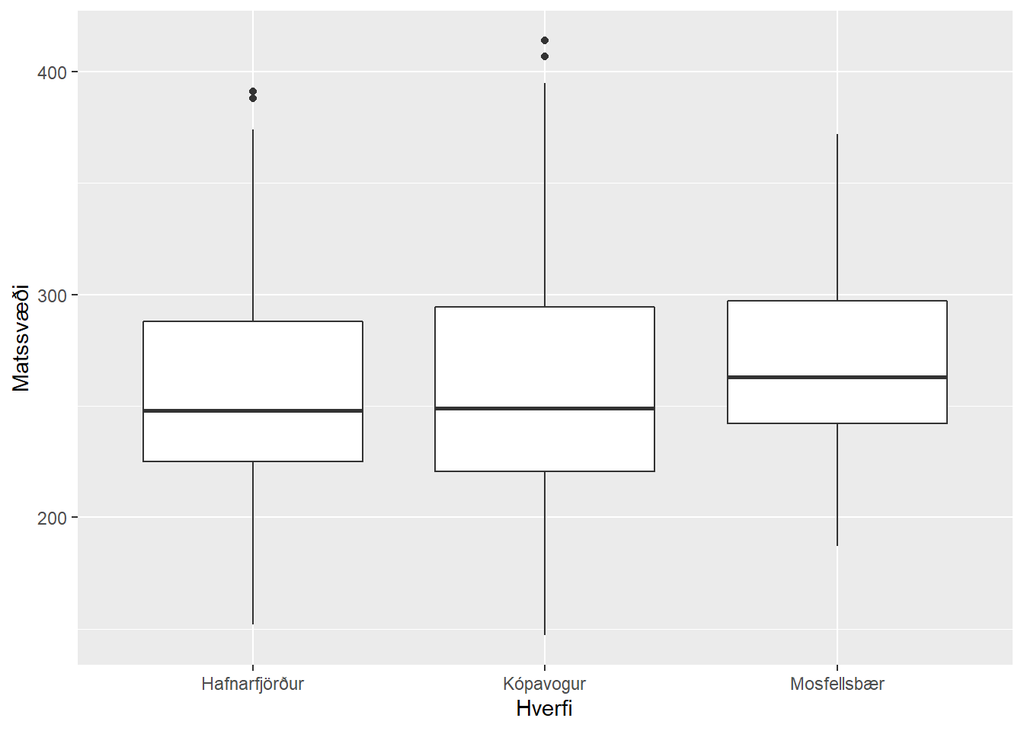

```r
ggplot(urtak, aes(x = matssvaedi, y = fermetraverd)) + geom_boxplot() + labs(x = "Hverfi", y = "Matssvæði")
```

Notum fervikagreiningu þar sem:

H0: Það er enginn munur á meðaltölum

H1: Það er munur á meðaltölum

```r
fervik <- aov(fermetraverd ~ matssvaedi, data = urtak)
#anova(fervik)
summary(fervik)
```

```
##              Df Sum Sq Mean Sq F value Pr(>F)
## matssvaedi    2  14340    7170   2.864 0.0582 .
## Residuals   397 993766    2503
## ---
## Signif. codes:  0 '***' 0.001 '**' 0.01 '*' 0.05 '.' 0.1 ' ' 1
```

Þar sem p-gildið er hærra en alpha-gildið getum við ekki hafnað núlltilgátunni. Því getum við ekki ályktað að það sé munur á meðaltölum milli hverfa.

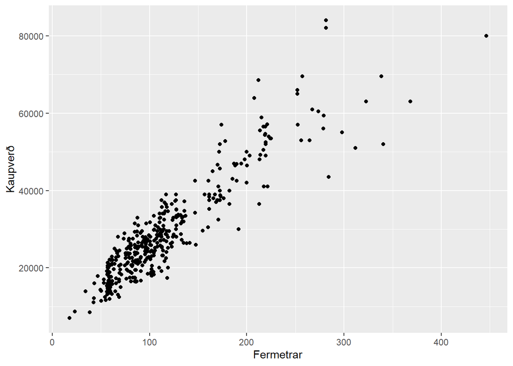

```r
ggplot(urtak, aes(x = birtm2, y = kaupverd)) + geom_point() + labs(x = "Fermetrar", y = "Kaupverð")
```

Eins og sést á myndinni væri mjög auðvelt að setja inn línu til að tákna sambandið á milli breytanna tveggja og því er viðeigandi að nota línulegt aðhvarf.

```r
lml <- lm(kaupverd ~ birtm2, data=urtak)
summary(lml)
```

```
##
## Call:
## lm(formula = kaupverd ~ birtm2, data = urtak)
##
## Residuals:
##    Min     1Q Median     3Q    Max
## -20939  -3022     -6   2806  22571
##
## Coefficients:
##             Estimate Std. Error t value Pr(>|t|)
## (Intercept) 6343.510    559.508   11.34   <2e-16 ***
## birtm2       195.755      4.278   45.75   <2e-16 ***
## ---
## Signif. codes:  0 '***' 0.001 '**' 0.01 '*' 0.05 '.' 0.1 ' ' 1
##
## Residual standard error: 5215 on 398 degrees of freedom
## Multiple R-squared:  0.8403, Adjusted R-squared:  0.8399
## F-statistic:  2093 on 1 and 398 DF,  p-value: < 2.2e-16
```

```r
confint(lml)
```

```
##                 2.5 %    97.5 %
## (Intercept) 5243.5503 7443.4704
## birtm2       187.3437  204.1659
```

Skurðpunktur við y-ás skv. aðhvarfsgreiningu er 6343.510 og hallatalan 195.755. Það sem þetta segir okkur er að verðið hækkar um 195.755 við hvern fermetra sem bætt er við.